# Atividade_Aula4

```r
library(tidyverse)
library(yfR)
library(GetQuandlData)
library(GetBCBData)
library(GetDFPData2)

options(scipen = 9999)
```

## Questao 1

Utilizando pacote yfR, baixe os dados da ação MDIA3 (ticker MDIA3.SA) no Yahoo Finance para os últimos 30 dias.

```r
tickers <- "MDIA3.SA"
first_date <- Sys.Date() - 30
last_date <- Sys.Date()

df_mdia3 <-
  yf_get(tickers = tickers,
         first_date = first_date,
         last_date = last_date)
```

```
── Running yfR for 1 stocks | 2023-08-02 --> 2023-09-01 (30 days) ──
```

```
ℹ Downloading data for benchmark ticker ^GSPC
```

```
ℹ (1/1) Fetching data for MDIA3.SA
```

```
!   - not cached
```

```
✔   - cache saved successfully
```

```
✔   - got 22 valid rows (2023-08-02 --> 2023-08-31)
```

```
✔   - got 100% of valid prices -- Youre doing good!
```

```
ℹ Binding price data
```

```
── Diagnostics ─────────────────────────────────────────────────────────────────
```

```
✔ Returned dataframe with 22 rows -- Well done !
```

```
ℹ Using 6.5 kB at C:\Users\luisg\AppData\Local\Temp\Rtmp2bBTpw/yf_cache for 2 cache files
```

```
ℹ Out of 1 requested tickers, you got 1 (100%)
```

```r
min(df_mdia3$price_adjusted)
```

```
[1] 37.2
```

### Qual o preço ajustado mais baixo no período analisado? Qual a data com o preço mais baixo? Faça um gráfico simples com função plot()

Resposta: 37.2

### Qual a data com o preço mais baixo?

```r
df_mdia3[which(df_mdia3$price_adjusted == min(df_mdia3$price_adjusted)), ]$ref_date
```

```
[1] "2023-08-31"
```

Reposta: 2023-08-31

### Faça um gráfico simples com função plot()

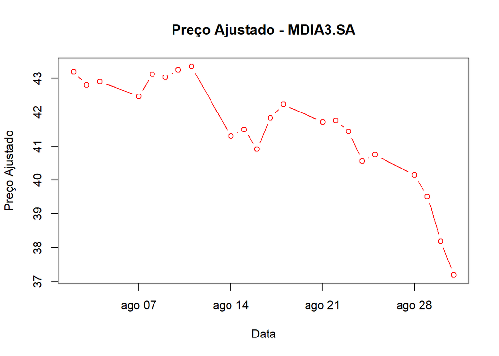

```r
plot(
  df_mdia3$ref_date,
  df_mdia3$price_adjusted,
  type = 'b',
  col =
    'red',
  main = paste('Preço Ajustado -', tickers),
  xlab = 'Data',
  ylab =
    'Preço Ajustado'
)
```

## Questao 2

Caso não o tenha feito, crie um perfil no site do Quandl e salve o seu código de API. Com pacote GetQuandlData, baixe os dados da população brasileira do banco de dados do IMF entre 2000-01-01 e 2023-09-01.

### Qual é o último valor disponível?

```r
api_key <- readRDS('./conf/quantdl_ID.RDS')

my_symbol <- c('IMF' = 'ODA/BRA_LP')
first_date <- '2000-01-01'
last_date <- '2023-09-01'

df_br_pop <-
  get_Quandl_series(
    id_in = my_symbol,
    api_key = api_key,
    first_date = first_date,
    last_date = last_date
  )
```

```
Fetching data for ODA/BRA_LP (IMF)
```

```
    Series available from 1980-12-31 to 2024-12-31
```

```
    Returning 23 rows
```

```r
ultima_pop <-
  df_br_pop[df_br_pop$ref_date == max(df_br_pop$ref_date), ]$value

ultima_pop
```

```
[1] 213.862
```

### Qual é o último valor disponível?

Resposta: 213.862 milhões

## Questao 3

Utilize pacote GetBCBData para baixar dados do IPCA mensal (em % anual) nos últimos 5 anos. É possível observar algum período com deflação, inflação negativa, mensal?

```r
# 433 - Indice nacional de preços ao consumidor-amplo (IPCA)
id_series <- 433

ano <- as.integer(format(Sys.Date(), '%Y'))

# criar data 5 anos atras
ano5 <- ano - 5

first_date = paste0(ano5, '-01-01')

df_inf <- gbcbd_get_series(id = id_series,
                           first.date = first_date,
                           last.date = Sys.Date())
```

```
Fetching id = 433 [433] from BCB-SGS with cache
     Found 67 observations
```

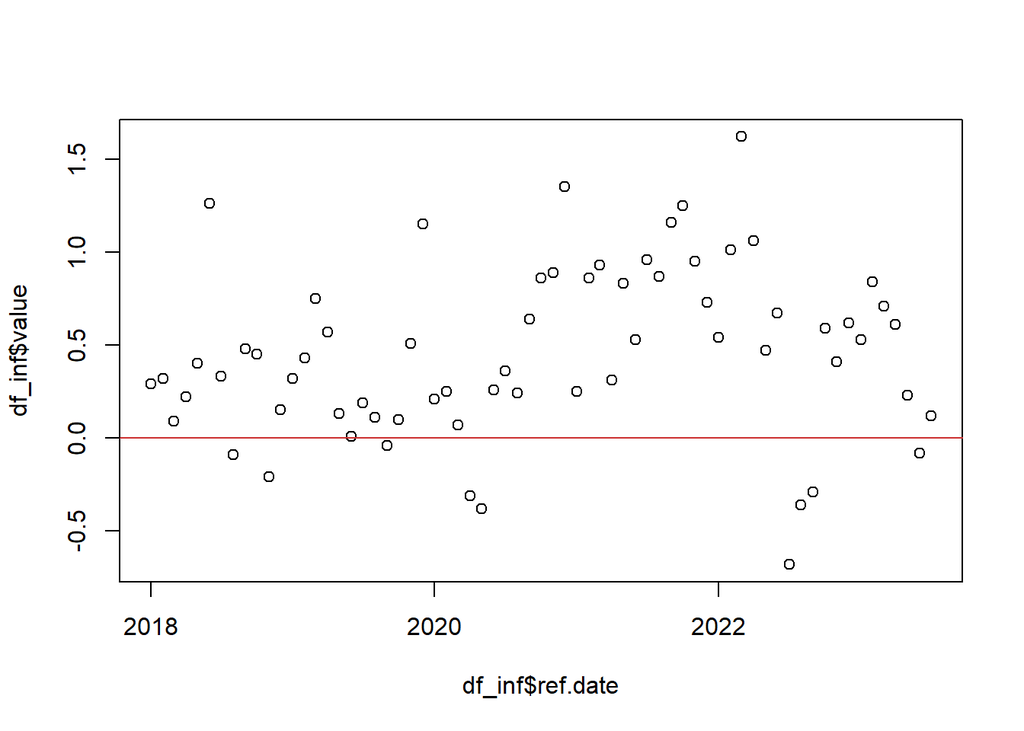

```r
plot(df_inf$ref.date, df_inf$value)
abline(h = 0, col = 'brown3')
```

```r
deflacao <- df_inf |>
  dplyr::filter(value < 0)

unique(deflacao$ref.date)
```

```
[1] "2018-08-01" "2018-11-01" "2019-09-01" "2020-04-01" "2020-05-01"
[6] "2022-07-01" "2022-08-01" "2022-09-01" "2023-06-01"
```

### É possível observar algum período com deflação, inflação negativa, mensal?

Resposta: Sim nos meses: 08/2018, 11/2018, 09/2019, 04/2020, 05/2020, 07/2022, 08/2022, 09/2022, 06/2023

## Questao 4

Visite o site de sistema de séries temporais do Banco Central do Brasil e escolha uma série para análise de acordo com seus próprios interesses de pesquisa. Importe a mesma usando pacote GetBCBData.

```r
# Serie - 7811 Taxa referencial (TR) - Primeiro dia do mês

id_series <- 7811

df_tr <- gbcbd_get_series(id = id_series, first.date = '2020-09-01')
```

```
Fetching id = 7811 [7811] from BCB-SGS with cache
     Found 36 observations
```

```r
summary(df_tr$value)
```

```
   Min. 1st Qu.  Median    Mean 3rd Qu.    Max.
0.00000 0.00000 0.05800 0.08471 0.16390 0.24090
```

```r
df_tr
```

```
     ref.date  value id.num series.name
1  2020-09-01 0.0000   7811   id = 7811
2  2020-10-01 0.0000   7811   id = 7811
3  2020-11-01 0.0000   7811   id = 7811
4  2020-12-01 0.0000   7811   id = 7811
5  2021-01-01 0.0000   7811   id = 7811
6  2021-02-01 0.0000   7811   id = 7811
7  2021-03-01 0.0000   7811   id = 7811
8  2021-04-01 0.0000   7811   id = 7811
9  2021-05-01 0.0000   7811   id = 7811
10 2021-06-01 0.0000   7811   id = 7811
11 2021-07-01 0.0000   7811   id = 7811
12 2021-08-01 0.0000   7811   id = 7811
13 2021-09-01 0.0000   7811   id = 7811
14 2021-10-01 0.0000   7811   id = 7811
```

[output cut: 22 more lines]

## Questao 5

Utilizando função GetDFPData2::get_info_companies, baixe informações sobre as ações negociadas na B3.

```r
df_info_b3 <- GetDFPData2::get_info_companies()
```

```
Fetching info on B3 companies
```

```
    Dowloading file from CVM
```

```
    File not found, downloading it..
```

```
    Success
```

```
    Reading file from CVM
```

```
    Saving cache data
```

```
    Got 2584 lines for 2450 companies [Actives = 699 Inactives = 1763]
```

```r
df_info_b3
```

```
# A tibble: 2,584 × 47
   CNPJ               DENOM_SOCIAL DENOM_COMERC DT_REG     DT_CONST   DT_CANCEL
   <chr>              <chr>        <chr>        <date>     <date>     <date>
 1 08.773.135/0001-00 2W ECOBANK … 2W ECOBANK … 2020-10-29 2007-03-23 NA
 2 11.396.633/0001-87 3A COMPANHI… TRIPLO A  C… 2010-03-08 2009-11-03 2015-12-18
 3 12.091.809/0001-55 3R PETROLEU… <NA>         2020-11-09 2010-06-08 NA
 4 01.547.749/0001-16 521 PARTICI… 521 PARTICI… 1997-07-11 1996-07-30 NA
 5 01.851.771/0001-55 524 PARTICI… 524 PARTICI… 1997-05-30 1997-04-02 NA
 6 01.919.008/0001-19 525 PARTICI… 525 PARTICI… 1997-07-16 1997-04-02 2006-05-30
 7 92.659.614/0001-06 A J RENNER … A J RENNER   1969-06-24 NA         1998-06-17
 8 02.288.752/0001-25 A.P. PARTIC… A.P. PARTIC… 1998-01-21 1997-12-14 2004-12-23
 9 21.649.280/0001-33 ABC DADOS E… ABC COMPUTA… 1988-06-03 NA         1993-03-05
10 02.258.274/0001-00 ABC SUPERME… ABC SUPERME… 1998-02-27 1997-09-30 2001-12-17
# ℹ 2,574 more rows
# ℹ 41 more variables: MOTIVO_CANCEL <chr>, SIT_REG <chr>, DT_INI_SIT <date>,
#   CD_CVM <dbl>, SETOR_ATIV <chr>, TP_MERC <chr>, CATEG_REG <chr>,
#   DT_INI_CATEG <date>, SIT_EMISSOR <chr>, DT_INI_SIT_EMISSOR <date>,
#   CONTROLE_ACIONARIO <chr>, TP_ENDER <chr>, LOGRADOURO <chr>, COMPL <chr>,
#   BAIRRO <chr>, MUN <chr>, UF <chr>, PAIS <chr>, CEP <dbl>, DDD_TEL <chr>,
#   TEL <dbl>, DDD_FAX <chr>, FAX <dbl>, EMAIL <chr>, TP_RESP <chr>, …
```

### Quantas empresas no total estão atualmente disponíveis no banco de dados?

```r
nrow(df_info_b3)
```

```
[1] 2584
```

Resposta: 2584

### Qual a proporção de empresas ativas (veja coluna SIT_REG)?

```r
prop.table(table(df_info_b3$SIT_REG))*100
```

```
                    ATIVO                 CANCELADA SUSPENSO(A) - DECISÃO ADM
               30.2631579                69.6207430                 0.1160991
```

Resposta: 30.263 % das empresas estão ativas.

### Qual a empresa mais antiga (veja coluna DT_REG)?

```r
df_info_b3 |>
  dplyr::filter(DT_REG == min(df_info_b3$DT_REG)) |>
  dplyr::select(DT_REG, DENOM_SOCIAL)
```

```
# A tibble: 1 × 2
  DT_REG     DENOM_SOCIAL
  <date>     <chr>
1 1923-05-23 COTONIFICIO BELTRAMO SA
```

Resposta: Empresa mais antiga é COTONIFICIO BELTRAMO SA, com data de registro 23/05/1923

### Quantas empresas existem para o setor de “Alimentos”?

```r
df_info_b3 |>
  dplyr::filter(SETOR_ATIV == 'Alimentos') |>
  head()
```

```
# A tibble: 6 × 47
  CNPJ  DENOM_SOCIAL DENOM_COMERC DT_REG     DT_CONST   DT_CANCEL  MOTIVO_CANCEL
  <chr> <chr>        <chr>        <date>     <date>     <date>     <chr>
1 60.5… ANDERSON CL… ANDERSON CL… 1977-07-20 NA         1987-12-23 ELISÃO POR I…
2 02.5… ARAGUAIA CI… ARAGUAIA     1973-11-29 NA         1987-06-05 CANCELAMENTO…
3 15.1… BARRETTO AR… BARRETO DE … 1984-05-16 NA         2010-01-04 Cancelamento…
4 28.5… BELPRATO SA  BELPRATO     1989-05-19 NA         2006-03-21 CANCELAMENTO…
5 60.6… BLUE TECH S… BLUE TECH S… 1985-03-14 1972-06-16 NA         <NA>
6 10.8… BOA SAFRA S… BOA SAFRA S… 2021-04-19 2009-04-07 NA         <NA>
# ℹ 40 more variables: SIT_REG <chr>, DT_INI_SIT <date>, CD_CVM <dbl>,
#   SETOR_ATIV <chr>, TP_MERC <chr>, CATEG_REG <chr>, DT_INI_CATEG <date>,
#   SIT_EMISSOR <chr>, DT_INI_SIT_EMISSOR <date>, CONTROLE_ACIONARIO <chr>,
#   TP_ENDER <chr>, LOGRADOURO <chr>, COMPL <chr>, BAIRRO <chr>, MUN <chr>,
#   UF <chr>, PAIS <chr>, CEP <dbl>, DDD_TEL <chr>, TEL <dbl>, DDD_FAX <chr>,
#   FAX <dbl>, EMAIL <chr>, TP_RESP <chr>, RESP <chr>, DT_INI_RESP <date>,
#   LOGRADOURO_RESP <chr>, COMPL_RESP <chr>, BAIRRO_RESP <chr>, …
```

```r
df_info_b3 |>
  dplyr::filter(SETOR_ATIV == 'Alimentos') |>
  nrow()
```

```
[1] 111
```

Resposta: Existem 111 empresas do setor de Alimentos.

## Questao 6

Com pacote GetDFPData2, baixe os demostrativos financeiros mais recentes da Petrobras.

```r
id_companies <- 9512
first_year <- 2015
last_year  <- 2022

demonstracoes <- GetDFPData2::get_dfp_data(
  companies_cvm_codes = id_companies,
  type_docs = '*',
  type_format = 'con',
  first_year = first_year,
  last_year = last_year
)
```

```
    Dowloading dfp_cia_aberta_2015.zip
```

```
    File not found, downloading it..
```

```
    Success
```

```
        Unzipping
```

[output not shown]

[output cut: 37 more lines]

[output not shown]

```r
# conferir nome da companhia
unique(demonstracoes$`DF Consolidado - Balanço Patrimonial Ativo`$DENOM_CIA)
```

```
[1] "PETROLEO BRASILEIRO S.A. PETROBRAS"
```

### Qual foi o seu lucro líquido no exercício?

```r
df_dre <- demonstracoes$`DF Consolidado - Demonstração do Resultado`

df_dre |>
  dplyr::filter(CD_CONTA == '3.11') |>
  dplyr::mutate(VL_CONTA2 = VL_CONTA * 1e3) |>
  dplyr::select(DT_REFER, VL_CONTA2)
```

```
# A tibble: 8 × 2
  DT_REFER      VL_CONTA2
  <date>            <dbl>
1 2015-12-31 -35171000000
2 2016-12-31 -13045000000
3 2017-12-31    377000000
4 2018-12-31  26698000000
5 2019-12-31  40970000000
6 2020-12-31   6246000000
7 2021-12-31 107264000000
8 2022-12-31 189005000000
```

Resposta: Lucro do último exercício foi de 189,005 bilhões

### Qual foi o pagamento de proventos para o acionista (dividendo ou JSCP) mais recente?

```r
df_dfc <- demonstracoes$`DF Consolidado - Demonstração do Fluxo de Caixa (Método Indireto)`

df_dfc |>
  select(DS_CONTA, CD_CONTA) |>
  dplyr::filter(str_detect(DS_CONTA, pattern = 'Dividendos Pagos') == T |
                str_detect(DS_CONTA, pattern = 'Juros') == T) |>
  distinct() |>
  arrange(CD_CONTA)
```

```
# A tibble: 5 × 2
  DS_CONTA                                        CD_CONTA
  <chr>                                           <chr>
1 Amortizações de Juros                           6.03.04
2 Dividendos Pagos a Acionistas                   6.03.05
3 Dividendos Pagos a acionistas Petrobras         6.03.05
4 Dividendos Pagos a Acionistas não controladores 6.03.06
5 Dividendos Pagos a acionistas não controladores 6.03.06
```

Fazer a seleção das contas de Dividendos pagos a acionistas e JSCP

```r
df_pagtos <- df_dfc |>
  dplyr::filter(str_detect(DS_CONTA, pattern = 'Dividendos Pagos') == T |
                str_detect(DS_CONTA, pattern = 'Juros') == T) |>
  dplyr::filter(str_detect(DS_CONTA, pattern = 'Amortizações de Juros', negate = T) == T)

df_pagtos |>
  dplyr::filter(DT_REFER == max(DT_REFER)) |>
  dplyr::select(DT_REFER, DS_CONTA, VL_CONTA) |>
  mutate(VL_CONTA * 1e3)
```

```
# A tibble: 2 × 4
  DT_REFER   DS_CONTA                                 VL_CONTA `VL_CONTA * 1000`
  <date>     <chr>                                       <dbl>             <dbl>
1 2020-12-31 Dividendos Pagos a acionistas Petrobras  -6209000       -6209000000
2 2020-12-31 Dividendos Pagos a acionistas não contr…  -448000        -448000000
```

Resposta: São dois pagamentos feitos em 31/12/2020:

R$ 6.209.000.000 - Dividendos Pagos a acionistas Petrobras

R$ 448.000.000 - Dividendos Pagos a Acionistas não controladores

## Questao 7

Com base no pacote GetTDData, baixe dados para títulos do tipo LTN (Letras Financeiras do Tesouro) entre 2022-04-19 e 2023-09-01.

```r
asset_codes <- 'LTN'   # Identifier of assets
first_year <- 2022
last_year <- 2023

df_TD <- GetTDData::td_get(asset_codes,
                           first_year = first_year,
                           last_year = last_year)
```

```
── Downloading TD files
```

```
ℹ Downloading LTN_2022.xls
```

```
✔   'C:/Users/luisg/AppData/Local/Temp/Rtmp2bBTpw/td-files/LTN/LTN_2022.xls' is found, with size 175.6 kB.
```

```
ℹ Downloading LTN_2023.xls
```

```
✔   'C:/Users/luisg/AppData/Local/Temp/Rtmp2bBTpw/td-files/LTN/LTN_2023.xls' is found, with size 105.5 kB.
```

```
── Checking files
```

```
✔ Found 2 files
```

```
── Reading files
```

```
ℹ Reading 'C:/Users/luisg/AppData/Local/Temp/Rtmp2bBTpw/td-files/LTN/LTN_2022.xls'
```

```
✔   Reading Sheet LTN 010123
```

```
✔   Reading Sheet LTN 010724
```

```
✔   Reading Sheet LTN 010125
```

```
✔   Reading Sheet LTN 010126
```

```
✔   Reading Sheet LTN 010129
```

```
ℹ Reading 'C:/Users/luisg/AppData/Local/Temp/Rtmp2bBTpw/td-files/LTN/LTN_2023.xls'
```

```
✔   Reading Sheet LTN 010724
```

```
✔   Reading Sheet LTN 010125
```

```
✔   Reading Sheet LTN 010126
```

```
✔   Reading Sheet LTN 010129
```

```r
df_TD <-  df_TD |>
  dplyr::filter(ref_date >= as.Date('2022-04-19') &
                                      ref_date <= as.Date('2023-09-01'))
```

### Entre todas LTNs, qual o título com maior data de vencimento?

```r
df_TD |>
  dplyr::filter(matur_date == max(matur_date)) |>
  dplyr::pull(asset_code) |>
  unique()
```

```
[1] "LTN 010129"
```

Resposta: o título com maior vencimento é LTN 010129

### Entre todas LTNs, qual o título de menor preço atualmente (última data)?

```r
df_TD |>
  dplyr::filter(ref_date == max(ref_date)) |>
  dplyr::filter(price_bid == min(price_bid)) |>
  dplyr::pull(asset_code) |>
  unique()
```

```
[1] "LTN 010129"
```

Resposta: o título menor preço (da última data) é LTN 010129